# final_project_v3

### Note:

This is **the third version** of the final project. Below is the list of modifications I made from the second version.

- Included graphs showing the scores of each K value for **SelectKBest**.
- In **the second version**, due to the randomness, I decided not to use the **feature importances** in **Decision Tree** when selecting the best features. In this version, I used this method to remove lowest one at a time iteratively.
- Enhanced the performance by using **cv** parameter in **GridSearchCV**.
- Used **Pipeline** to rescale the data set more easily.
- Used **KNeighborClassifier** instead of **KNeighborRegressor**.
- Only used **Decision Tree** and **KNN** for the classifiers. Excluded **GaussianNB**, **SVM** and **Logistic Regression**.
- Included the importance of **parameter tuning** in the **Final Thoughts**.

# Identifying POI from Enron Dataset

### Final Project - Machine Learning Course

### Udacity Data Analyst Nanodegree

This is the final project for the machine learning course. Enron financial data and email data will be investigated to find the list of person of interest (POI) who were involved in the fraud activities.

Below is the order of the investigation process I will employ for this final project.

- Univariate analysis
  - Process the dataset (taking care of missing values and outliers)
  - Select good features that don't have too many zeros or missing values
  - Calculate accuracy, precision and recall for each feature I selected using classifiers with default parameters.
- Bivariate analysis
  - Use features that show the high scores from the univariate analysis
  - Calculate accuracy, precision and recall from a pair of features using more classifiers and various parameters.
- Multivariate analysis
  - Calculate accuracy, precision and recall from features with the best scores from univariate and bivariate analysis.

In the end, I will choose the combination of features and classifier that shows the best scores.

First, necessary Libraries will be loaded.

```python
#!/usr/bin/python

import sys
import pickle
import pprint
import matplotlib.pyplot as plt
import numpy as np

### Setting the path
sys.path.append("../tools/")

### These are the scripts given in the class
from feature_format import featureFormat, targetFeatureSplit
from tester import dump_classifier_and_data
```

Load the dictionary containing the dataset.

```python
### Load the dictionary containing the dataset
with open("final_project_dataset.pkl", "r") as data_file:
    data_dict = pickle.load(data_file)
```

```python
len(data_dict)
```

```
146
```

There are total 146 number of data in data_dict. I am going to print out the first two of the data from data_dict to see how the dictionary looks like.

```python
stop = 0
for k, v in data_dict.iteritems():
    print k
    pprint.pprint(v)
    if stop == 1:
        break
    stop += 1
```

```
METTS MARK
{'bonus': 600000,
 'deferral_payments': 'NaN',
 'deferred_income': 'NaN',
 'director_fees': 'NaN',
 'email_address': 'mark.metts@enron.com',
 'exercised_stock_options': 'NaN',
 'expenses': 94299,
 'from_messages': 29,
 'from_poi_to_this_person': 38,
 'from_this_person_to_poi': 1,
 'loan_advances': 'NaN',
 'long_term_incentive': 'NaN',
 'other': 1740,
 'poi': False,
 'restricted_stock': 585062,
 'restricted_stock_deferred': 'NaN',
 'salary': 365788,
 'shared_receipt_with_poi': 702,
 'to_messages': 807,
 'total_payments': 1061827,
 'total_stock_value': 585062}
BAXTER JOHN C
{'bonus': 1200000,
 'deferral_payments': 1295738,
 'deferred_income': -1386055,
 'director_fees': 'NaN',
 'email_address': 'NaN',
 'exercised_stock_options': 6680544,
 'expenses': 11200,
 'from_messages': 'NaN',
 'from_poi_to_this_person': 'NaN',
 'from_this_person_to_poi': 'NaN',
 'loan_advances': 'NaN',
 'long_term_incentive': 1586055,
 'other': 2660303,
 'poi': False,
 'restricted_stock': 3942714,
 'restricted_stock_deferred': 'NaN',
 'salary': 267102,
 'shared_receipt_with_poi': 'NaN',
 'to_messages': 'NaN',
 'total_payments': 5634343,
 'total_stock_value': 10623258}
```

The keys of data_dict are the names of people and the values are various features. Every feature except poi and email_address are numerical values. It looks like it is either a number of 'NaN' when the data is missing. And poi is a boolean value that I can use to find POI's.

```python
### Finding the number of features
for k,v in data_dict.iteritems():
    print "The number of features:", len(v)
    features_list = v.keys() # features are saved separately for later use

    ### Save the raw features
    total_features_list = v.keys()
    break
```

```
The number of features: 21
```

There are total 21 features in the dataset. I will ignore "email_address" because they are not numerical values. And I will ingore 'other' as well because I don't know what this is.

```python
### Removing poi and email_address
try:
    features_list.remove("email_address")
    features_list.remove("other")
except:
    pass
try:
    total_features_list.remove("email_address")
    total_features_list.remove("other")
except:
    pass

### Convert data_dict into numpy array
data = featureFormat(data_dict, features_list)
print "The type of data:", type(data)
print "The total number of data", data.shape
```

```
The type of data: <type 'numpy.ndarray'>
The total number of data (145L, 19L)
```

Now the data_dict is converted to numpy array. And it contains 145 rows and 19 columns. featureFormat ignores the "NaN" values and creates numpy array that I can use it for the analysis more easily.

Using data numpy array I will check the number of poi's and non-poi's.

```python
### Finding the index of poi
poi_ind = features_list.index("poi")

### Print out the number of poi and non-poi
print "The total number of poi:", np.sum(data[:,poi_ind])
print "The total number of non-poi:", np.size(data[:,poi_ind]) - np.sum(data[:,poi_ind])
```

```
The total number of poi: 18.0
The total number of non-poi: 127.0
```

There are total **18 POI** and **127 non-POI**.

```python
### Move poi column to the end
### data
tmp_data = data
tmp_data[:,-1] = data[:,poi_ind]
tmp_data[:,poi_ind] = data[:,-1]
data = tmp_data

### features_list
tmp = features_list[-1]
features_list[poi_ind] = tmp
features_list[-1] = "poi"

### Reassign poi index
poi_ind = features_list.index("poi")
```

I moved poi column to the end to use the data more easily.

## Plotting

From now on, I will start drawing various plots for univariate analysis and bivariate analysis. I will draw histograms for each feature first.

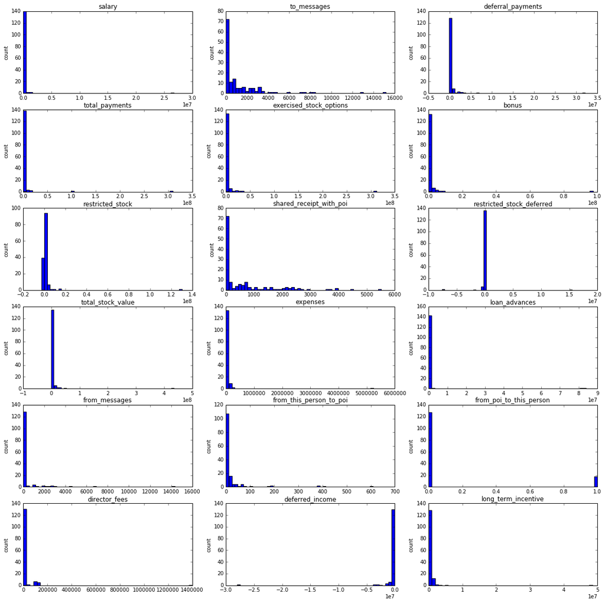

```python
### Create new features list without poi
features_list_new = [ii for ii in features_list if ii != "poi"]

%matplotlib inline
### 20 histograms for features
plt.rcParams["figure.figsize"] = (20,20)
f, axarr = plt.subplots(6, 3)

### the histogram of the data
### x: x coordinate values, y: y coordinate values
### r: row index, c: column index
### title: title of a subplot
def subplot_histogram(x, bins, r, c, title):
    axarr[r, c].hist(x, bins = bins)
    axarr[r, c].set_title(title)
    axarr[r, c].set_ylabel("count")

for i in range(len(features_list_new)):
    subplot_histogram(data[:,i],50,i/3,i%3,features_list_new[i])

plt.show()
```

Looking at these histograms, I can see there are outliers for every feature.

I will look into salary more deeply and see if there is any interesting thing going on.

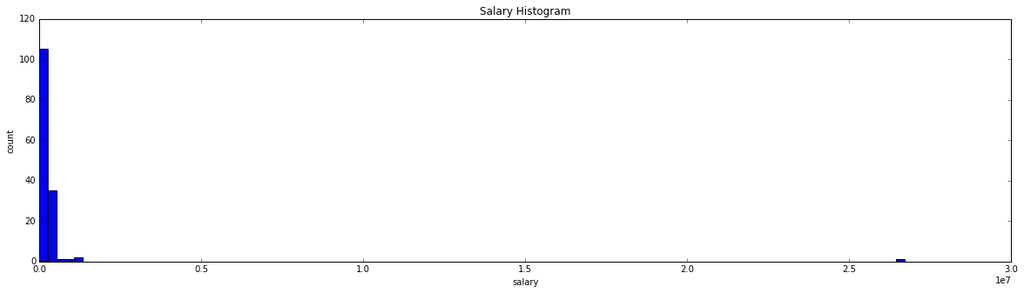

```python
%matplotlib inline
### Find indices for salary
salary_ind = features_list.index("salary")

### Set the size of the plot
plt.rcParams["figure.figsize"] = (20,5)

### Draw Salary histogram
plt.hist(data[:,salary_ind], bins=100)
plt.xlabel("salary")
plt.ylabel("count")
plt.title("Salary Histogram")
plt.show()
```

Now I will get rid of the outlier above 2.5e7 and replot the histogram

```
53408458.0 is the total sum of salaries
26704229.0 is removed
```

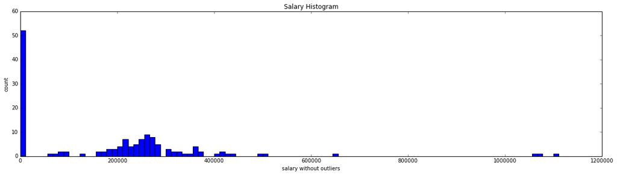

```python
### Total sum of salaries
import numpy as np
print np.sum(data[:,salary_ind]), "is the total sum of salaries"

### Create new array that contains salar values without outliers
salary_no_outliers = []
for i in data[:,salary_ind]:
    if i < 2.5e7:
        salary_no_outliers.append(i)
    else:
        print i, "is removed"

### Draw Salary histogram
plt.hist(salary_no_outliers, bins=100)
plt.xlabel("salary without outliers")
plt.ylabel("count")
plt.title("Salary Histogram")
plt.show()
```

The outlier removed is half of the total sum of salary array, which means someone added a total sum of salaries into the data. I believe that in data_dict there is a key that contains the sum of every feature.

```python
for k,v in data_dict.iteritems():
    if v["salary"] == 26704229.0:
        print k,v
```

```
TOTAL {'salary': 26704229, 'to_messages': 'NaN', 'deferral_payments': 32083396, 'total_payments': 309886585, 'exercised_stock_options': 311764000, 'bonus': 97343619, 'restricted_stock': 130322299, 'shared_receipt_with_poi': 'NaN', 'restricted_stock_deferred': -7576788, 'total_stock_value': 434509511…
```

As I expected one of the keys in data_dict is TOTAL. I will create a new dictionary that excludes this key.

```python
### New data_dict excluding TOTAL key
data_dict_new = {}

for k, v in data_dict.iteritems():
    if k != "TOTAL":
        data_dict_new[k] = v

### Print out the new data_dict length
print "The length of the new data_dict:", len(data_dict_new)
```

```
The length of the new data_dict: 145
```

Now there are 145 data in the data_dict_new. I will graph the histograms again.

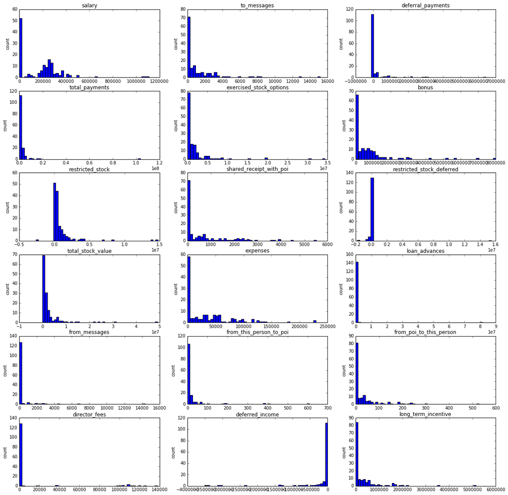

```python
### Convert data_dict_new into numpy array
data = featureFormat(data_dict_new, features_list)

%matplotlib inline
### 20 histograms for features
plt.rcParams["figure.figsize"] = (20,20)
f, axarr = plt.subplots(6, 3)

### the histogram of the data
### x: x coordinate values, y: y coordinate values
### r: row index, c: column index
### title: title of a subplot
def subplot_histogram(x, bins, r, c, title):
    axarr[r, c].hist(x, bins = bins)
    axarr[r, c].set_title(title)
    axarr[r, c].set_ylabel("count")

for i in range(len(features_list_new)):
    subplot_histogram(data[:,i],50,i/3,i%3,features_list_new[i])

plt.show()
```

The histograms are better than before. Although there are still outliers in histograms, getting rid of them might not be a good idea because those values may be helpful identifying POI's.

I suspect that some of these features will have too many zeros because featureFormat function convert NaN to zero in some cases. I will print out the number of zeros for each feature.

```python
### defining function that counts zeros
def counting_zeros(data, features_list, feature):
    total_count = 0
    count = 0
    feature_data = data[:,features_list.index(feature)]
    for i in feature_data:
        total_count += 1
        if i == 0:
            count += 1
    print "{}: {}, {}%".format(feature,count, int(float(count)*100/float(total_count)))

### Printing out the number of zeros for each feature
for i in features_list[:-1]:
    counting_zeros(data, features_list, i)
```

```
salary: 50, 34%
to_messages: 58, 40%
deferral_payments: 106, 73%
total_payments: 20, 13%
exercised_stock_options: 43, 29%
bonus: 63, 43%
restricted_stock: 35, 24%
shared_receipt_with_poi: 58, 40%
restricted_stock_deferred: 127, 88%
total_stock_value: 19, 13%
expenses: 50, 34%
loan_advances: 141, 97%
from_messages: 58, 40%
from_this_person_to_poi: 78, 54%
from_poi_to_this_person: 70, 48%
director_fees: 128, 88%
deferred_income: 96, 66%
long_term_incentive: 79, 54%
```

I will ignore features with more than 60% of zeros from now on.

### Features that will be ignored:

- deferral_payments
- restricted_stock_deferred
- loan_advances
- director_fees
- deferred_income

I will recreate data numpy array and features_list array that exclude the features above.

```python
### Save the original features_list before change
features_list_original = features_list

### list of features with too many zeros
too_many_zeros = ["deferral_payments",
                  "restricted_stock_deferred",
                  "loan_advances",
                  "director_fees",
                  "deferred_income"]

### remove the above features from features_list
for i in too_many_zeros:
    if i in features_list:
        features_list.remove(i)

### Convert data_dict_new into numpy array
data = featureFormat(data_dict_new, features_list)
print data.shape
```

```
(144L, 14L)
```

Now the number of columns of data is reduced to 14.

### Checking Scores

Now I am going to test each feature using GaussianNB and check the accuracy, precision and recall. Then I will use features with high values for later use.

I will employ tester functions from tester.

```python
### Import functions from tester_edited.py
from tester_edited import load_classifier_and_data, test_classifier
from sklearn.cross_validation import StratifiedShuffleSplit
```

This will be a repetitive process so I will create a function to do this. The code is from **tester.py**.

```python
### the code is from "poi_id.py" from final_project folder.
### this function will split the data into test and train
### apply classifier and calculate the accuracy, precision and recall
def test(features_list, clf, print_result=False, draw_graph=False, rescale=False):
    ### Store to my_dataset for easy export below.
    my_dataset = data_dict

    ### Extract features and labels from dataset for local testing
    data = featureFormat(my_dataset, features_list, sort_keys = True)
    labels, features = targetFeatureSplit(data)

#     ### Split train and test by 30 %
#     from sklearn.cross_validation import train_test_split
#     features_train, features_test, labels_train, labels_test = \
#         train_test_split(features, labels, test_size=0.3, random_state=42)

    ### Dump the data to the local files
    dump_classifier_and_data(clf, my_dataset, features_list)

    ### Load the data from the local files
    clf, dataset, feature_list = load_classifier_and_data()

    ### Print out the result
    scores = test_classifier(
        clf, dataset, feature_list,
        print_result=print_result, draw_graph=draw_graph, rescale=rescale)
    return scores

### import GaussianNB
from sklearn.naive_bayes import GaussianNB

### import Decision Tree
from sklearn import tree

### This function only test the data using
### GaussianNB and Decision Tree
def classify_simple(features_list, print_result=False):
    print "Features list:", features_list[1:]

    ### Set GaussianNB
    clf_NB = GaussianNB()

    ### Set Decision Tree
    clf_tree = tree.DecisionTreeClassifier()

    ### Call test function and print out test
    scores_NB = test(features_list,clf_NB, print_result=print_result)
    tree_NB = test(features_list,clf_tree, print_result=print_result)
    return [ scores_NB, tree_NB ]
```

```python
### Always put poi at the zeroth index
classify_simple(["poi", "salary"],print_result=True)
```

```
Features list: ['salary']

GaussianNB()

	Best parameters:
	No GridSearch

	Accuracy: 0.25560	Precision: 0.18481	Recall: 0.79800	F1: 0.30011	F2: 0.47968
	Total predictions: 20000	True positives: 3192	False positives: 14080	False negatives:  808	True negatives: 1920


DecisionTreeClassifier(class_weight=None, criterion='gini', max_depth=None,
            max_features=None, max_leaf_nodes=None, min_samples_leaf=1,
            min_samples_split=2, min_weight_fraction_leaf=0.0,
            presort=False, random_state=None, splitter='best')

	Best parameters:
	No GridSearch

	Accuracy: 0.69210	Precision: 0.23619	Recall: 0.24150	F1: 0.23881	F2: 0.24042
	Total predictions: 20000	True positives:  966	False positives: 3124	False negatives: 3034	True negatives: 12876
```

```
[[0.2556, 0.18480778138026865, 0.798, {}],
 [0.6921, 0.23618581907090463, 0.2415, {}]]
```

I ran the function using poi and salary. Fortunately the function works.

I will use this function for all the other features.

```python
### Iterate over the features_list
scores_list = {}
for i in features_list[:-1]:
    scores_list[i] = classify_simple(["poi", i])
```

```
Features list: ['salary']
Features list: ['to_messages']
Got a divide by zero when trying out: GaussianNB()
Precision or recall may be undefined due to a lack of true positive predicitons.

Features list: ['total_payments']
Features list: ['exercised_stock_options']
Features list: ['bonus']
Features list: ['restricted_stock']
Features list: ['shared_receipt_with_poi']
Got a divide by zero when trying out: GaussianNB()
Precision or recall may be undefined due to a lack of true positive predicitons.

Features list: ['total_stock_value']
Features list: ['expenses']
Features list: ['from_messages']
Got a divide by zero when trying out: GaussianNB()
Precision or recall may be undefined due to a lack of true positive predicitons.

Features list: ['from_this_person_to_poi']
Got a divide by zero when trying out: GaussianNB()
Precision or recall may be undefined due to a lack of true positive predicitons.

Features list: ['from_poi_to_this_person']
Features list: ['long_term_incentive']
```

```python
### Print out scores of each feature
print "      Accuarcy Precision Recall"
for k,v in scores_list.iteritems():
    print k
    if v[0] == None:
        print "NB     ---------None---------"
    else:
        print "NB     {0:.4f}  {1:.4f}  {2:.4f}".format(v[0][0], v[0][1], v[0][2])
    print "tree   {0:.4f}  {1:.4f}  {2:.4f}".format(v[1][0], v[1][1], v[1][2])
```

```
      Accuarcy Precision Recall
salary
NB     0.2556  0.1848  0.7980
tree   0.6921  0.2362  0.2415
to_messages
NB     ---------None---------
tree   0.7371  0.0856  0.1410
total_payments
NB     0.7631  0.0694  0.0435
tree   0.7393  0.0804  0.0665
bonus
NB     0.3780  0.2223  0.7200
tree   0.7623  0.4427  0.2685
total_stock_value
NB     0.8406  0.3200  0.0320
tree   0.7584  0.2300  0.2430
shared_receipt_with_poi
NB     ---------None---------
tree   0.8421  0.3020  0.3210
exercised_stock_options
NB     0.8994  0.2108  0.0390
tree   0.8571  0.2686  0.3320
from_messages
NB     ---------None---------
tree   0.7259  0.0067  0.0100
from_this_person_to_poi
NB     ---------None---------
tree   0.7444  0.0218  0.0180
long_term_incentive
NB     0.3980  0.1471  0.6700
tree   0.6943  0.0250  0.0300
expenses
NB     0.3068  0.1885  0.7460
tree   0.6466  0.1295  0.1340
restricted_stock
NB     0.7380  0.1013  0.0560
tree   0.7297  0.1196  0.0765
from_poi_to_this_person
NB     0.7365  0.0263  0.0015
tree   0.6425  0.1312  0.0765
```

```python
### list of features with too many zeros above 50%
too_many_zeros = ["to_messages",
                  "shared_receipt_with_poi",
                  "from_messages",
                  "from_this_person_to_poi",
                  "total_payments"]

### remove the above features from features_list
for i in too_many_zeros:
    if i in features_list:
        features_list.remove(i)

### Convert data_dict_new into numpy array
data = featureFormat(data_dict_new, features_list)
print "Shape of data:", data.shape
pprint.pprint(features_list)
```

```
Shape of data: (139L, 9L)
['salary',
 'exercised_stock_options',
 'bonus',
 'restricted_stock',
 'total_stock_value',
 'expenses',
 'from_poi_to_this_person',
 'long_term_incentive',
 'poi']
```

The number of columns are reduced to 9 including poi. Let's print the result again only from these features.

```python
### Print out scores of each feature
print "      Accuarcy Precision Recall"
for k,v in scores_list.iteritems():
    if k in features_list:
        print k
        if v[0] == None:
            print "NB     ---------None---------"
        else:
            print "NB     {0:.4f}  {1:.4f}  {2:.4f}".format(v[0][0], v[0][1], v[0][2])
        print "tree   {0:.4f}  {1:.4f}  {2:.4f}".format(v[1][0], v[1][1], v[1][2])
```

```
      Accuarcy Precision Recall
salary
NB     0.2556  0.1848  0.7980
tree   0.6921  0.2362  0.2415
bonus
NB     0.3780  0.2223  0.7200
tree   0.7623  0.4427  0.2685
total_stock_value
NB     0.8406  0.3200  0.0320
tree   0.7584  0.2300  0.2430
exercised_stock_options
NB     0.8994  0.2108  0.0390
tree   0.8571  0.2686  0.3320
long_term_incentive
NB     0.3980  0.1471  0.6700
tree   0.6943  0.0250  0.0300
expenses
NB     0.3068  0.1885  0.7460
tree   0.6466  0.1295  0.1340
restricted_stock
NB     0.7380  0.1013  0.0560
tree   0.7297  0.1196  0.0765
from_poi_to_this_person
NB     0.7365  0.0263  0.0015
tree   0.6425  0.1312  0.0765
```

From the result above, the features with the best scores are **bonus**, **exercised_stock_options** and **total_stock_value**. I will use these features as my main dependent variables for the bivariate analysis.

## Selecting features using SelectKBest and Decision Tree Features Importance

The above selection is choosing the features with few zeros. However, having many zeros not necessarily means the data is bad.

In the previous version, I found **14** features with the best scores using **SelectKBest**. And **14** is a number I chose randomly so it doesn't have any significance. In this version, I will find the number that maximize the performance using **SelectKBest**.

```python
### Convert data_dict_new into numpy array
total_data = featureFormat(data_dict_new, total_features_list)

print total_data.shape

### Extract features from the data
features = total_data
features = np.delete(features, total_features_list.index("poi"), 1)

### Extract a label from the data
label = total_data[:,total_features_list.index("poi")]

### Rescale features
from sklearn.preprocessing import MinMaxScaler
min_max_scaler = MinMaxScaler()
features = min_max_scaler.fit_transform(features)

### Import SelectKBest
from sklearn.feature_selection import SelectKBest
from sklearn.feature_selection import f_classif

pre_selected_list = []
features_by_importance = []
for k in range(1,19):
    selector = SelectKBest(f_classif, k=k)
    selector = selector.fit(features,label)

    features_list_wo_poi = [i for i in total_features_list if i!="poi"] ### features list without poi

    ### Print features chosen by SelectKBest
    selected_list = [features_list_wo_poi[i] for i in range(len(features_list_wo_poi)) if selector.get_support()[i]]

    print "K:", k
    for i in selected_list:
        if i not in pre_selected_list:
            print "\t", i
            features_by_importance.append(i)

    pre_selected_list = selected_list
```

```
(144L, 19L)
K: 1
	exercised_stock_options
K: 2
	total_stock_value
K: 3
	bonus
K: 4
	salary
K: 5
	deferred_income
K: 6
	long_term_incentive
K: 7
	restricted_stock
K: 8
	total_payments
K: 9
	shared_receipt_with_poi
K: 10
	loan_advances
K: 11
	expenses
K: 12
	from_poi_to_this_person
K: 13
	from_this_person_to_poi
K: 14
	director_fees
K: 15
	to_messages
K: 16
	deferral_payments
K: 17
	from_messages
K: 18
	restricted_stock_deferred
```

The above shows the features that are selected by its importance. The best feature is **exercised_stock_option** and the next best feature is **total_stock_value** and so on. Now I will calculate the scores for each **k** value using **Decision Tree**.

```python
### Import Cross Validation
from sklearn.cross_validation import StratifiedShuffleSplit

### Import MinMaxScaler
from sklearn.preprocessing import MinMaxScaler
min_max_scaler = MinMaxScaler()

### Import DecisionTree Classifier
clf = tree.DecisionTreeClassifier(criterion='gini', splitter='random', min_samples_split=5)

### Use pipeline
from sklearn.pipeline import Pipeline
pipe = Pipeline(steps=[('minmaxer', min_max_scaler), ('clf', clf)])

### Set up the print format
PERF_FORMAT_STRING = "\
\tAccuracy: {:>0.{display_precision}f}\tPrecision: {:>0.{display_precision}f}\t\
Recall: {:>0.{display_precision}f}\tF1: {:>0.{display_precision}f}\tF2: {:>0.{display_precision}f}"
RESULTS_FORMAT_STRING = "\tTotal predictions: {:4d}\tTrue positives: {:4d}\tFalse positives: {:4d}\
\tFalse negatives: {:4d}\tTrue negatives: {:4d}"

### Set up the arrays for precision, recall and F1
precision_list = []
recall_list = []
f1_list = []

### Calculate scores for each K value
for i in range(len(features_by_importance)):
    selected_features_list = features_by_importance[:(i+1)]
    selected_features_list.insert(0,'poi')
    selected_data = featureFormat(data_dict_new, selected_features_list)

    ### Split the data into labels and features
    labels, features = targetFeatureSplit(selected_data)

    cv = StratifiedShuffleSplit(labels, 1000, random_state = 42)
    true_negatives = 0
    false_negatives = 0
    true_positives = 0
    false_positives = 0

    for train_idx, test_idx in cv:
        features_train = []
        features_test  = []
        labels_train   = []
        labels_test    = []
        for ii in train_idx:
            features_train.append( features[ii] )
            labels_train.append( labels[ii] )
        for jj in test_idx:
            features_test.append( features[jj] )
            labels_test.append( labels[jj] )

            features_test.append( features[jj])
            labels_test.append( labels[jj] )


        ### fit the classifier using training set, and test on test set
        pipe.fit(features_train, labels_train)
        try:
            print clf.best_params_
            for k,v in clf.best_params_.iteritems():
                if k in best_params_collector:
                    best_params_collector[k].append(v)
                else:
                    best_params_collector[k] = [v]
        except:
            pass

        predictions = pipe.predict(features_test)
        for prediction, truth in zip(predictions, labels_test):
            ### Assign prediction either 0 or 1
            if prediction < .5:
                prediction = 0
            else:
                prediction = 1

            if prediction == 0 and truth == 0:
                true_negatives += 1
            elif prediction == 0 and truth == 1:
                false_negatives += 1
            elif prediction == 1 and truth == 0:
                false_positives += 1
            elif prediction == 1 and truth == 1:
                true_positives += 1
    try:
        total_predictions = true_negatives + false_negatives + false_positives + true_positives
        accuracy = 1.0*(true_positives + true_negatives)/total_predictions
        precision = 1.0*true_positives/(true_positives+false_positives)
        recall = 1.0*true_positives/(true_positives+false_negatives)
        f1 = 2.0 * true_positives/(2*true_positives + false_positives+false_negatives)
        f2 = (1+2.0*2.0) * precision*recall/(4*precision + recall)

        print selected_features_list[-1]
        print PERF_FORMAT_STRING.format(accuracy, precision, recall, f1, f2, display_precision = 5)

        precision_list.append(precision)
        recall_list.append(recall)
        f1_list.append(f1)

    except:
        print "Precision or recall may be undefined due to a lack of true positive predicitons.\n"
```

```
exercised_stock_options
	Accuracy: 0.91418	Precision: 0.55983	Recall: 0.26200	F1: 0.35695	F2: 0.29320
total_stock_value
	Accuracy: 0.83231	Precision: 0.40702	Recall: 0.19700	F1: 0.26550	F2: 0.21967
bonus
	Accuracy: 0.83446	Precision: 0.44548	Recall: 0.31050	F1: 0.36594	F2: 0.33053
salary
	Accuracy: 0.82662	Precision: 0.40770	Recall: 0.28050	F1: 0.33235	F2: 0.29917
deferred_income
	Accuracy: 0.82607	Precision: 0.35432	Recall: 0.26450	F1: 0.30289	F2: 0.27863
long_term_incentive
	Accuracy: 0.82236	Precision: 0.33492	Recall: 0.24700	F1: 0.28432	F2: 0.26069
restricted_stock
	Accuracy: 0.81786	Precision: 0.32258	Recall: 0.25000	F1: 0.28169	F2: 0.26178
total_payments
	Accuracy: 0.82533	Precision: 0.31144	Recall: 0.25600	F1: 0.28101	F2: 0.26545
shared_receipt_with_poi
	Accuracy: 0.82367	Precision: 0.30746	Recall: 0.25750	F1: 0.28027	F2: 0.26615
loan_advances
	Accuracy: 0.82053	Precision: 0.29837	Recall: 0.25600	F1: 0.27557	F2: 0.26348
expenses
	Accuracy: 0.82467	Precision: 0.32402	Recall: 0.29000	F1: 0.30607	F2: 0.29622
from_poi_to_this_person
	Accuracy: 0.82007	Precision: 0.30573	Recall: 0.27500	F1: 0.28955	F2: 0.28064
from_this_person_to_poi
	Accuracy: 0.82067	Precision: 0.30769	Recall: 0.27600	F1: 0.29099	F2: 0.28181
director_fees
	Accuracy: 0.81827	Precision: 0.30033	Recall: 0.27300	F1: 0.28601	F2: 0.27806
to_messages
	Accuracy: 0.81633	Precision: 0.28828	Recall: 0.25700	F1: 0.27174	F2: 0.26270
deferral_payments
	Accuracy: 0.81960	Precision: 0.30519	Recall: 0.27650	F1: 0.29014	F2: 0.28180
from_messages
	Accuracy: 0.81793	Precision: 0.29773	Recall: 0.26900	F1: 0.28264	F2: 0.27429
restricted_stock_deferred
	Accuracy: 0.81687	Precision: 0.29579	Recall: 0.27050	F1: 0.28258	F2: 0.27521
```

Scores for each **K** value are calculated above. The feature is appended to the list and the scores are calculated one at a time. According to the result, **Recall** is the highest when **K** is 3.

Let's graph the result.

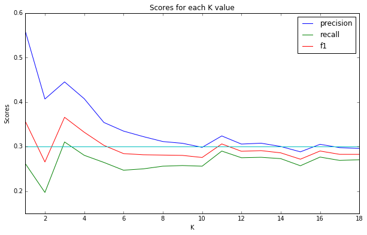

```python
%matplotlib inline
### Set the size of the plot
plt.rcParams["figure.figsize"] = (10,6)

### Set up the x-axis
k_values = range(1,len(recall_list)+1)

### Draw Salary histogram
plt.plot(k_values, precision_list, k_values, recall_list, k_values, f1_list)

x = [1,18]
y = [.3,.3]
plt.plot(x,y)

plt.xlim([1,18])

plt.legend(['precision','recall','f1'])
plt.xlabel("K")
plt.ylabel("Scores")
plt.title("Scores for each K value")
plt.show()
```

I drew a horizontal line at **0.3** because it is the threshold given from the rubric. There is only 1 value of **K** when all of these scores are above **0.3** and that is when **K** is 3.

These are the features selected by **SelectKBest**.

```
- exercised_stock_options
- total_stock_value
- bonus
```

Now I will choose the best features using **Feature Importance** in **Decision Tree** algorithm.

Below is the process I will employ to find the best features using **Feature Importance**.

1. Start from the list containing all of the features.
2. Calculate the scores with the list using **Decision Tree**.
3. Calculate **Feature Importance** for each feature in the list.
4. Drop the feature with the lowest **Importance**.
5. Go back to **step 2** and repeat the process.

```python
### Use GridSearchCV to find the best parameters
from sklearn.grid_search import GridSearchCV

### Import DecisionTree Classifier
clf = tree.DecisionTreeClassifier()
param_grid = {
    'criterion': ['gini', 'entropy'],
    'splitter' : ['best', 'random'],
    'min_samples_split': range(2,9)
      }

### Set up the arrays for precision, recall and F1
precision_list = []
recall_list = []
f1_list = []

if 'poi' not in total_features_list:
    total_features_list.append('poi')

selected_features_list = [i for i in total_features_list if i != 'poi']
features_by_importance = []

### Calculate scores for each K value
for i in range(len(total_features_list)-1):
    print

    try:
        print "Dropped Feature:", features_by_importance[-1]
    except:
        pass

    selected_features_list_with_poi = ['poi']
    selected_features_list_with_poi.extend(selected_features_list)

    selected_data = featureFormat(data_dict_new, selected_features_list_with_poi)

    ### Split the data into labels and features
    labels, features = targetFeatureSplit(selected_data)

    ### Recale the features
    features = min_max_scaler.fit_transform(features)

    cv = StratifiedShuffleSplit(labels, 100, random_state = 42)

    clf_grid = GridSearchCV(clf, param_grid, cv = cv, scoring = 'recall')

    clf_grid.fit(features, labels)

    print clf_grid.best_params_

    clf.set_params(criterion=clf_grid.best_params_["criterion"],
                   splitter=clf_grid.best_params_["splitter"],
                   min_samples_split=clf_grid.best_params_["min_samples_split"])

    true_negatives = 0
    false_negatives = 0
    true_positives = 0
    false_positives = 0

    for train_idx, test_idx in cv:
        features_train = []
        features_test  = []
        labels_train   = []
        labels_test    = []
        for ii in train_idx:
            features_train.append( features[ii] )
            labels_train.append( labels[ii] )
        for jj in test_idx:
            features_test.append( features[jj] )
            labels_test.append( labels[jj] )

            features_test.append( features[jj])
            labels_test.append( labels[jj] )

        ### fit the classifier using training set, and test on test set
        clf.fit(features_train, labels_train)

        predictions = clf.predict(features_test)
        for prediction, truth in zip(predictions, labels_test):
            ### Assign prediction either 0 or 1
            if prediction < .5:
                prediction = 0
            else:
                prediction = 1

            if prediction == 0 and truth == 0:
                true_negatives += 1
            elif prediction == 0 and truth == 1:
                false_negatives += 1
            elif prediction == 1 and truth == 0:
                false_positives += 1
            elif prediction == 1 and truth == 1:
                true_positives += 1

    total_predictions = true_negatives + false_negatives + false_positives + true_positives
    accuracy = 1.0*(true_positives + true_negatives)/total_predictions
    precision = 1.0*true_positives/(true_positives+false_positives)
    recall = 1.0*true_positives/(true_positives+false_negatives)
    f1 = 2.0 * true_positives/(2*true_positives + false_positives+false_negatives)
    f2 = (1+2.0*2.0) * precision*recall/(4*precision + recall)


    print PERF_FORMAT_STRING.format(accuracy, precision, recall, f1, f2, display_precision = 5)
    importances = clf.feature_importances_

    precision_list.append(precision)
    recall_list.append(recall)
    f1_list.append(f1)

    ### Find the index of the feature with the lowest importance
    min_importance = min(importances)
    features_by_importance.append(selected_features_list[np.argmin(importances)])
    selected_features_list.remove(selected_features_list[np.argmin(importances)])
```

```
Dropped Feature: {'min_samples_split': 2, 'splitter': 'random', 'criterion': 'gini'}
	Accuracy: 0.80133	Precision: 0.26667	Recall: 0.28000	F1: 0.27317	F2: 0.27723

Dropped Feature: to_messages
{'min_samples_split': 2, 'splitter': 'random', 'criterion': 'gini'}
	Accuracy: 0.80733	Precision: 0.27861	Recall: 0.28000	F1: 0.27930	F2: 0.27972

Dropped Feature: deferral_payments
{'min_samples_split': 4, 'splitter': 'random', 'criterion': 'entropy'}
	Accuracy: 0.82667	Precision: 0.32143	Recall: 0.27000	F1: 0.29348	F2: 0.27893

Dropped Feature: total_payments
{'min_samples_split': 2, 'splitter': 'random', 'criterion': 'gini'}
	Accuracy: 0.80533	Precision: 0.28095	Recall: 0.29500	F1: 0.28780	F2: 0.29208

Dropped Feature: restricted_stock_deferred
{'min_samples_split': 2, 'splitter': 'random', 'criterion': 'gini'}
	Accuracy: 0.81000	Precision: 0.27027	Recall: 0.25000	F1: 0.25974	F2: 0.25381

Dropped Feature: loan_advances
{'min_samples_split': 2, 'splitter': 'random', 'criterion': 'gini'}
	Accuracy: 0.80267	Precision: 0.25510	Recall: 0.25000	F1: 0.25253	F2: 0.25100

Dropped Feature: director_fees
{'min_samples_split': 2, 'splitter': 'random', 'criterion': 'gini'}
	Accuracy: 0.80867	Precision: 0.30667	Recall: 0.34500	F1: 0.32471	F2: 0.33659

Dropped Feature: restricted_stock
{'min_samples_split': 3, 'splitter': 'random', 'criterion': 'gini'}
	Accuracy: 0.81867	Precision: 0.31633	Recall: 0.31000	F1: 0.31313	F2: 0.31124

Dropped Feature: from_this_person_to_poi
{'min_samples_split': 2, 'splitter': 'random', 'criterion': 'gini'}
	Accuracy: 0.80267	Precision: 0.29832	Recall: 0.35500	F1: 0.32420	F2: 0.34200

Dropped Feature: from_poi_to_this_person
{'min_samples_split': 5, 'splitter': 'random', 'criterion': 'gini'}
	Accuracy: 0.83333	Precision: 0.36979	Recall: 0.35500	F1: 0.36224	F2: 0.35786

Dropped Feature: exercised_stock_options
```

[output cut: 15 more lines]

```
Dropped Feature: long_term_incentive
{'min_samples_split': 4, 'splitter': 'random', 'criterion': 'entropy'}
	Accuracy: 0.80857	Precision: 0.32292	Recall: 0.31000	F1: 0.31633	F2: 0.31250

Dropped Feature: deferred_income
{'min_samples_split': 2, 'splitter': 'best', 'criterion': 'gini'}
	Accuracy: 0.82786	Precision: 0.41202	Recall: 0.48000	F1: 0.44342	F2: 0.46467

Dropped Feature: bonus
{'min_samples_split': 2, 'splitter': 'best', 'criterion': 'gini'}
	Accuracy: 0.80571	Precision: 0.32000	Recall: 0.32000	F1: 0.32000	F2: 0.32000

Dropped Feature: expenses
{'min_samples_split': 5, 'splitter': 'best', 'criterion': 'gini'}
	Accuracy: 0.76923	Precision: 0.25248	Recall: 0.25500	F1: 0.25373	F2: 0.25449
```

Let's graph the scores to look at the result more visually.

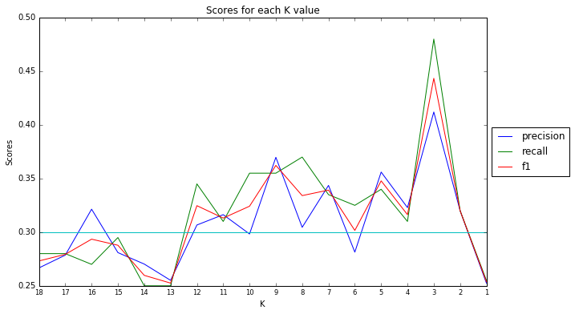

```python
%matplotlib inline
### Set the size of the plot
plt.rcParams["figure.figsize"] = (10,6)

### Set up the x-axis
k_values = range(1,len(recall_list)+1)

### Draw Salary histogram
plt.plot(k_values, precision_list, k_values, recall_list, k_values, f1_list)

x = [1,18]
y = [.3,.3]
plt.plot(x,y)

plt.xlim([1,18])

plt.legend(['precision','recall','f1'],loc='center left', bbox_to_anchor=(1, 0.5))
plt.xticks(k_values,['18','17','16','15','14','13','12','11','10','9','8','7','6','5','4','3','2','1'], size='small')
plt.xlabel("K")
plt.ylabel("Scores")
plt.title("Scores for each K value")
plt.show()
```

- The best **Precision** is attained when **K** is 3.
- The best **Recall** is attained when **K** is 3.
- The best **F1** is attained when **K** is 3.

In this particular result, 3 seems to be the most optimized value for **K**.

Let's look at the list of these 3 features.

```python
features_by_importance[-3:]
```

```
['bonus', 'expenses', 'total_stock_value']
```

As I mentioned above, the result will be changed if I run this code again.

# Bivariate Analysis

In the **3rd** version of the final project, I removed most of the analysis I made in the 2nd version because we found that the number of features with the most optimized results are greater or equal to 3.

The purpose of the bivariate analysis in this version is to create a new feature by looking at the pairs of features from the list.

```python
### Set the poi_ind
poi_ind = features_list.index("poi")

%matplotlib inline
### Set the size of the plot
plt.rcParams["figure.figsize"] = (6,6)

### function for scatter plots
def scatter_plotting(x,y):
    ### Find index of x and y
    x_ind = features_list.index(x)
    y_ind = features_list.index(y)

    ### Create arrays for salary and bonus for poi and non-poi
    x_poi    = [data[:,x_ind][ii] for ii in range(0, len(data[:,0])) if data[:,poi_ind][ii]]
    y_poi    = [data[:,y_ind][ii] for ii in range(0, len(data[:,0])) if data[:,poi_ind][ii]]
    x_nonpoi = [data[:,x_ind][ii] for ii in range(0, len(data[:,0])) if not data[:,poi_ind][ii]]
    y_nonpoi = [data[:,y_ind][ii] for ii in range(0, len(data[:,0])) if not data[:,poi_ind][ii]]

    ### Draw Salary histogram
    plt.scatter(x_poi,   y_poi,   color="r",label="poi")
    plt.scatter(x_nonpoi,y_nonpoi,color="b",label="non-poi")
    plt.legend(loc='center left', bbox_to_anchor=(1, 0.5))
    plt.xlabel(x)
    plt.ylabel(y)
    plt.title("{} and {}".format(x, y))
    plt.show()
```

I will draw 3 by 3 subplots showing the scatter plots between either bonus, exercised_option_prices or total_stock_value and anything else in the features_list.

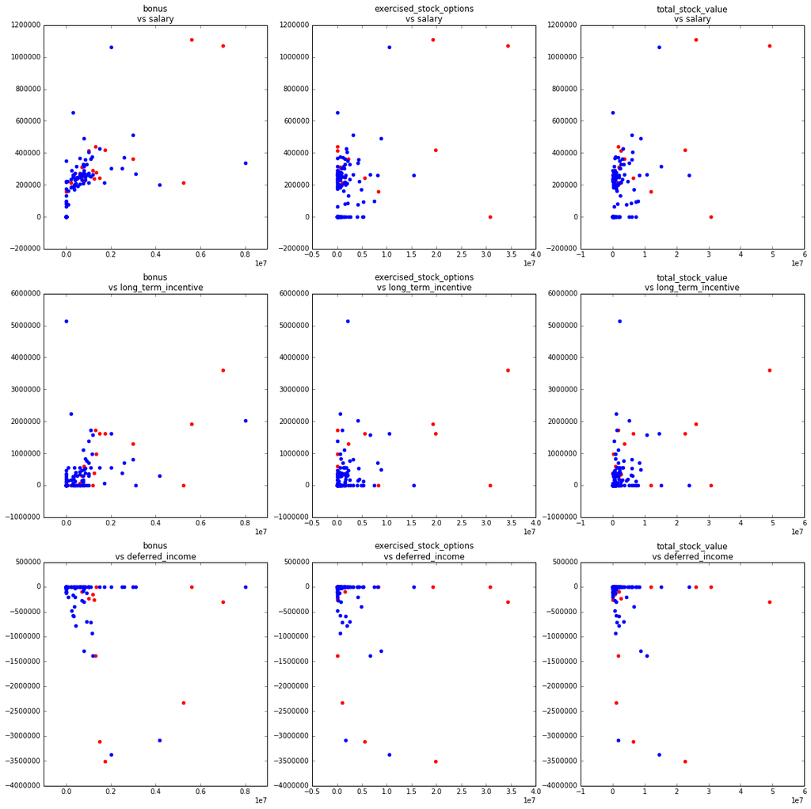

```python
%matplotlib inline
### 15 histograms for features
plt.rcParams["figure.figsize"] = (20,20)
f, axarr = plt.subplots(3, 3)

### Set up the data
data = featureFormat(data_dict_new, total_features_list)

### Set the poi index
poi_ind = total_features_list.index('poi')

### the scatter plots of the data
### x: x coordinate values, y: y coordinate values
### r: row index, c: column index
### title: title of a subplot
def subplot_scatter_plot(x, y, r, c):
    ### Find index of x and y
    x_ind = total_features_list.index(x)
    y_ind = total_features_list.index(y)

    ### Create arrays for salary and bonus for poi and non-poi
    x_poi    = [data[:,x_ind][ii] for ii in range(0, len(data[:,0])) if data[:,poi_ind][ii]]
    y_poi    = [data[:,y_ind][ii] for ii in range(0, len(data[:,0])) if data[:,poi_ind][ii]]
    x_nonpoi = [data[:,x_ind][ii] for ii in range(0, len(data[:,0])) if not data[:,poi_ind][ii]]
    y_nonpoi = [data[:,y_ind][ii] for ii in range(0, len(data[:,0])) if not data[:,poi_ind][ii]]

    ### Draw Salary histogram
    axarr[r,c].scatter(x_poi,   y_poi,   color="r",label="poi")
    axarr[r,c].scatter(x_nonpoi,y_nonpoi,color="b",label="non-poi")
    axarr[r,c].set_title("{}\nvs {}".format(x,y))

### Setting x coordinate values and y coordinate values
x_values = ["bonus", "exercised_stock_options", "total_stock_value"]
y_values = ["salary", "long_term_incentive", "deferred_income"]

r = 0
c = 0
for y in y_values:
    for x in x_values:
        subplot_scatter_plot(x,y,r,c)
        c = (c+1) % 3
    r += 1

plt.show()
```

### Creating a new feature

Based on the above plots, the blue dots have greater slopes than the red dots in the scatter plot of **exercised_stock_options** and **deferred_income**. I decided to create a new feature by dividing **deferred_income** from **exercised_stock_options** weighted by the sum of the squares of these features to the power of 0.2. I used *log* to get a better distribution.

```python
### Rescale each feature
from sklearn.preprocessing import MinMaxScaler
min_max_scaler = MinMaxScaler()

### Insert new key to the dictionary for each person
for k,v in data_dict_new.iteritems():
    di = (v["deferred_income"])
    es = (v["exercised_stock_options"])

    if di == "NaN" or es == "NaN":
        v["eso_deferred_income"] = 0.0
    elif di*es == 0:
        v["eso_deferred_income"] = 0.0
    else:
        es = float(es)
        di = float(di)
        v["eso_deferred_income"] = np.log(np.abs(es/di) * np.power(di*di + es*es, .2))

### Add the new feature to the features_list
if "eso_deferred_income" not in features_list:
    features_list.append("eso_deferred_income")

features_list_tmp = ["poi","eso_deferred_income"]
data_new_feature = featureFormat(data_dict_new, features_list_tmp)

### Split the data into labels and features
labels, features = targetFeatureSplit(data_new_feature)

### Rescale the new feature
features = min_max_scaler.fit_transform(features)
```

The code above appends the new feature to the existing data numpy array. In the code I set the new feature's value equal to 0 when the denominator is zero or the numerator is zero to avoid having *inf* values.

Then I scaled the new feature to 0 to 1.

### Plotting a new feature

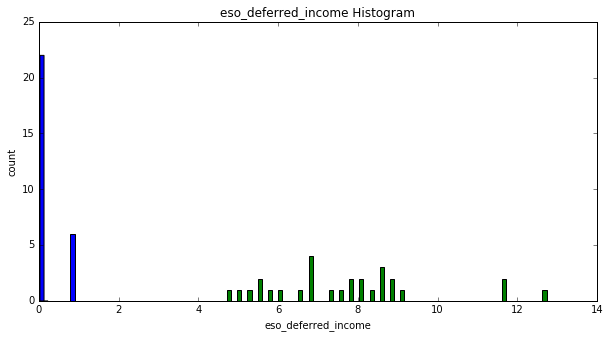

```python
### Draw eso_expenses histogram
plt.rcParams["figure.figsize"] = (10,5)
plt.hist(data_new_feature, bins=50)
plt.xlabel("eso_deferred_income")
plt.ylabel("count")
plt.title("eso_deferred_income Histogram")
plt.show()
```

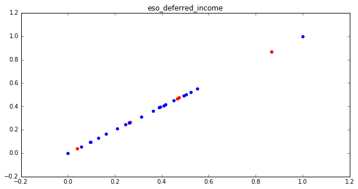

```python
### Create arrays for salary and bonus for poi and non-poi
x_poi    = [features[ii] for ii in range(0, len(features)) if labels[ii]]
x_nonpoi = [features[ii] for ii in range(0, len(features)) if not labels[ii]]

### Draw Salary histogram
plt.scatter(x_poi,   x_poi,   color="r",label="poi")
plt.scatter(x_nonpoi,x_nonpoi,color="b",label="non-poi")
plt.title("eso_deferred_income")

plt.show()
```

## Testing the new feature - Decision Tree

I will run Decision Tree with this new feature and other features.

```python
### Import a classifier library
from sklearn.neighbors import KNeighborsClassifier

### Setting features array and label array
data_features_only = np.delete(data, features_list.index("poi"), 1)
labels = data[:, features_list.index("poi")]

### Take out poi from the features list
features_list_wo_poi = [i for i in features_list if i != "poi"]

### Rescale features
min_max_scaler = MinMaxScaler()
data_features_only = min_max_scaler.fit_transform(data_features_only)

### Format the result
PERF_FORMAT_STRING = "\
\tAccuracy: {:>0.{display_precision}f}\tPrecision: {:>0.{display_precision}f}\t\
Recall: {:>0.{display_precision}f}\tF1: {:>0.{display_precision}f}\tF2: {:>0.{display_precision}f}"
RESULTS_FORMAT_STRING = "\tTotal predictions: {:4d}\tTrue positives: {:4d}\tFalse positives: {:4d}\
\tFalse negatives: {:4d}\tTrue negatives: {:4d}"
```

Above codes are setting up what's necessary to run Decision Tree. Major of them are identical to the codes in **tester.py** file.

First of all, features and labels arrays are created and rescaled with **MinMaxScaler**.

Decision Tree with the best parameters are set up and for the cross validation, I am going to use **StratifiedShuffleSplit**. Since there are only 18 POIs, when using test and train split, the test data most likely would end up having no POIs. So folding the number of data will fix such problem.

```python
### Calculate scores
### if classi is Decision Tree then calculate scores of the pairs of the new feature with other features using Decision Tree
### if classi is KNN then scores using KNN
def calculate_with_clf(classi):
    precision_list = []
    recall_list = []
    f1_list = []

    other_feature = [i for i in features_list_wo_poi if i != "eso_deferred_income"]
    for fe in other_feature:
        selected_features_list_with_poi = ['poi', 'eso_deferred_income']
        selected_features_list_with_poi.append(fe)

        selected_data = featureFormat(data_dict_new, selected_features_list_with_poi)

        ### Split the data into labels and features
        labels, features = targetFeatureSplit(selected_data)

        ### Recale the features
        features = min_max_scaler.fit_transform(features)

        ### Set up the validation
        cv = StratifiedShuffleSplit(labels, 100, random_state = 42)

        ### Set up the classifier
        if classi == "DecisionTree":
            clf = tree.DecisionTreeClassifier()
            param_grid = {
                'criterion': ['gini', 'entropy'],
                'splitter' : ['best', 'random'],
                'min_samples_split': range(2,10)
                  }

        elif classi == "KNN":
            clf = KNeighborsClassifier()
            param_grid = {
                'n_neighbors': [1,2,3,4,5,6,7,8,9,10],
                'weights': ['uniform', 'distance'],
                'algorithm': ['auto','ball_tree','kd_tree','brute']
                }

        cv = StratifiedShuffleSplit(labels, 100, random_state = 42)

        clf_grid = GridSearchCV(clf, param_grid, cv = cv, scoring = 'recall')

        clf_grid.fit(features, labels)

        if classi == "DecisionTree":
            clf.set_params(criterion=clf_grid.best_params_["criterion"],
                           splitter=clf_grid.best_params_["splitter"],
                           min_samples_split=clf_grid.best_params_["min_samples_split"])
        elif classi == "KNN":
            clf.set_params(n_neighbors=clf_grid.best_params_["n_neighbors"],
                           weights=clf_grid.best_params_["weights"],
                           algorithm=clf_grid.best_params_["algorithm"])

        print clf.get_params

        true_negatives = 0
        false_negatives = 0
        true_positives = 0
        false_positives = 0

        ### Getting train and test data sets
        for train_idx, test_idx in cv:
            features_train = []
            features_test  = []
            labels_train   = []
            labels_test    = []
            for ii in train_idx:
                features_train.append( features[ii] )
                labels_train.append( labels[ii] )
            for jj in test_idx:
                features_test.append( features[jj] )
                labels_test.append( labels[jj] )

                features_test.append( features[jj])
                labels_test.append( labels[jj] )


            ### fit the classifier using training set, and test on test set
            clf.fit(features_train, labels_train)

            predictions = clf.predict(features_test)
            for prediction, truth in zip(predictions, labels_test):
                ### Assign prediction either 0 or 1
                if prediction < .5:
                    prediction = 0
                else:
                    prediction = 1

                if prediction == 0 and truth == 0:
                    true_negatives += 1
                elif prediction == 0 and truth == 1:
                    false_negatives += 1
                elif prediction == 1 and truth == 0:
                    false_positives += 1
                elif prediction == 1 and truth == 1:
                    true_positives += 1

        try:
            total_predictions = true_negatives + false_negatives + false_positives + true_positives
            accuracy = 1.0*(true_positives + true_negatives)/total_predictions
            precision = 1.0*true_positives/(true_positives+false_positives)
            recall = 1.0*true_positives/(true_positives+false_negatives)
            f1 = 2.0 * true_positives/(2*true_positives + false_positives+false_negatives)
            f2 = (1+2.0*2.0) * precision*recall/(4*precision + recall)
            print "eso_deferred_income and", fe
            print PERF_FORMAT_STRING.format(accuracy, precision, recall, f1, f2, display_precision = 5)
            print RESULTS_FORMAT_STRING.format(total_predictions, true_positives, false_positives, false_negatives, true_negatives)
            print ""

            precision_list.append(precision)
            recall_list.append(recall)
            f1_list.append(f1)

        except:
            print "Got a divide by zero when trying out:", clf
            print "Precision or recall may be undefined due to a lack of true positive predicitons.\n"
    return (precision_list, recall_list, f1_list, other_feature)
```

```python
precision_list_1, recall_list_1, f1_list_1, other_feature = calculate_with_clf("DecisionTree")
```

```
<bound method DecisionTreeClassifier.get_params of DecisionTreeClassifier(class_weight=None, criterion='entropy', max_depth=None,
            max_features=None, max_leaf_nodes=None, min_samples_leaf=1,
            min_samples_split=2, min_weight_fraction_leaf=0.0,
            presort=False, random_state=None, splitter='best')>
eso_deferred_income and salary
	Accuracy: 0.69300	Precision: 0.20112	Recall: 0.18000	F1: 0.18997	F2: 0.18386
	Total predictions: 2000	True positives:   72	False positives:  286	False negatives:  328	True negatives: 1314

<bound method DecisionTreeClassifier.get_params of DecisionTreeClassifier(class_weight=None, criterion='gini', max_depth=None,
            max_features=None, max_leaf_nodes=None, min_samples_leaf=1,
            min_samples_split=4, min_weight_fraction_leaf=0.0,
            presort=False, random_state=None, splitter='best')>
eso_deferred_income and to_messages
	Accuracy: 0.82200	Precision: 0.21739	Recall: 0.30000	F1: 0.25210	F2: 0.27881
	Total predictions: 2000	True positives:   60	False positives:  216	False negatives:  140	True negatives: 1584

<bound method DecisionTreeClassifier.get_params of DecisionTreeClassifier(class_weight=None, criterion='gini', max_depth=None,
            max_features=None, max_leaf_nodes=None, min_samples_leaf=1,
            min_samples_split=2, min_weight_fraction_leaf=0.0,
            presort=False, random_state=None, splitter='random')>
eso_deferred_income and deferral_payments
	Accuracy: 0.73667	Precision: 0.21569	Recall: 0.22000	F1: 0.21782	F2: 0.21912
	Total predictions: 1200	True positives:   44	False positives:  160	False negatives:  156	True negatives:  840

<bound method DecisionTreeClassifier.get_params of DecisionTreeClassifier(class_weight=None, criterion='entropy', max_depth=None,
            max_features=None, max_leaf_nodes=None, min_samples_leaf=1,
            min_samples_split=4, min_weight_fraction_leaf=0.0,
            presort=False, random_state=None, splitter='best')>
eso_deferred_income and total_payments
	Accuracy: 0.78308	Precision: 0.24051	Recall: 0.19000	F1: 0.21229	F2: 0.19833
	Total predictions: 2600	True positives:   76	False positives:  240	False negatives:  324	True negatives: 1960

<bound method DecisionTreeClassifier.get_params of DecisionTreeClassifier(class_weight=None, criterion='entropy', max_depth=None,
            max_features=None, max_leaf_nodes=None, min_samples_leaf=1,
            min_samples_split=2, min_weight_fraction_leaf=0.0,
            presort=False, random_state=None, splitter='best')>
eso_deferred_income and exercised_stock_options
	Accuracy: 0.85636	Precision: 0.28358	Recall: 0.38000	F1: 0.32479	F2: 0.35581
	Total predictions: 2200	True positives:   76	False positives:  192	False negatives:  124	True negatives: 1808

```

[output cut: 88 more lines]

```
<bound method DecisionTreeClassifier.get_params of DecisionTreeClassifier(class_weight=None, criterion='entropy', max_depth=None,
            max_features=None, max_leaf_nodes=None, min_samples_leaf=1,
            min_samples_split=2, min_weight_fraction_leaf=0.0,
            presort=False, random_state=None, splitter='random')>
eso_deferred_income and long_term_incentive
	Accuracy: 0.62125	Precision: 0.17197	Recall: 0.13500	F1: 0.15126	F2: 0.14107
	Total predictions: 1600	True positives:   54	False positives:  260	False negatives:  346	True negatives:  940

<bound method DecisionTreeClassifier.get_params of DecisionTreeClassifier(class_weight=None, criterion='gini', max_depth=None,
            max_features=None, max_leaf_nodes=None, min_samples_leaf=1,
            min_samples_split=2, min_weight_fraction_leaf=0.0,
            presort=False, random_state=None, splitter='random')>
eso_deferred_income and from_poi_to_this_person
	Accuracy: 0.72500	Precision: 0.29508	Recall: 0.27000	F1: 0.28198	F2: 0.27467
	Total predictions: 2000	True positives:  108	False positives:  258	False negatives:  292	True negatives: 1342
```

```
18
18
```

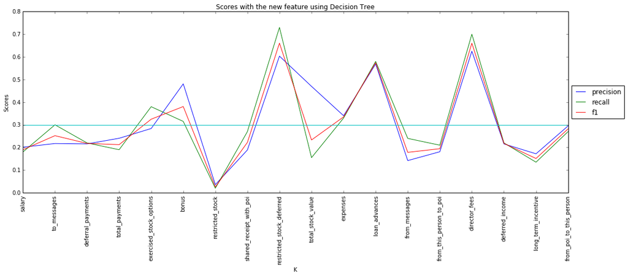

```python
%matplotlib inline
### Set the size of the plot
plt.rcParams["figure.figsize"] = (18,6)

### Set up the x-axis
k_values = range(len(precision_list_1))

print len(k_values)
print len(other_feature)
### Draw Salary histogram
plt.plot(k_values, precision_list_1, k_values, recall_list_1, k_values, f1_list_1)

x = [0,18]
y = [.3,.3]
plt.plot(x,y)

plt.xlim([0,len(precision_list_1)-1])

plt.legend(['precision','recall','f1'],loc='center left', bbox_to_anchor=(1, 0.5))
plt.xticks(k_values,other_feature, rotation='vertical')
plt.xlabel("K")
plt.ylabel("Scores")
plt.title("Scores with the new feature using Decision Tree")
plt.show()
```

One noticiable result is that there are three highest peaks at **restricted_stock_deferred**, **loan_advances** and **director_fees**.

Below is the summary of those top results.

```python
top_3_results = ["restricted_stock_deferred", "loan_advances", "director_fees"]

print "                       Precision  Recall      F1"
for i in top_3_results:
    print i
    ind = other_feature.index(i)
    print "                        {:.4f}    {:.4f}    {:.4f}".format(precision_list_1[ind], recall_list_1[ind], f1_list_1[ind])
```

```
                       Precision  Recall      F1
restricted_stock_deferred
                        0.6033    0.7300    0.6606
loan_advances
                        0.5686    0.5800    0.5743
director_fees
                        0.6250    0.7000    0.6604
```

## Testing the new feature - KNN

This time I will calculate the new feature using **KNN** classifier.

```python
precision_list, recall_list, f1_list, other_feature = calculate_with_clf("KNN")
```

```
<bound method KNeighborsClassifier.get_params of KNeighborsClassifier(algorithm='auto', leaf_size=30, metric='minkowski',
           metric_params=None, n_jobs=1, n_neighbors=1, p=2,
           weights='uniform')>
eso_deferred_income and salary
	Accuracy: 0.64700	Precision: 0.03067	Recall: 0.02500	F1: 0.02755	F2: 0.02596
	Total predictions: 2000	True positives:   10	False positives:  316	False negatives:  390	True negatives: 1284

<bound method KNeighborsClassifier.get_params of KNeighborsClassifier(algorithm='auto', leaf_size=30, metric='minkowski',
           metric_params=None, n_jobs=1, n_neighbors=1, p=2,
           weights='uniform')>
eso_deferred_income and to_messages
	Accuracy: 0.82900	Precision: 0.16190	Recall: 0.17000	F1: 0.16585	F2: 0.16832
	Total predictions: 2000	True positives:   34	False positives:  176	False negatives:  166	True negatives: 1624

<bound method KNeighborsClassifier.get_params of KNeighborsClassifier(algorithm='auto', leaf_size=30, metric='minkowski',
           metric_params=None, n_jobs=1, n_neighbors=1, p=2,
           weights='uniform')>
eso_deferred_income and deferral_payments
	Accuracy: 0.78500	Precision: 0.37391	Recall: 0.43000	F1: 0.40000	F2: 0.41748
	Total predictions: 1200	True positives:   86	False positives:  144	False negatives:  114	True negatives:  856

<bound method KNeighborsClassifier.get_params of KNeighborsClassifier(algorithm='auto', leaf_size=30, metric='minkowski',
           metric_params=None, n_jobs=1, n_neighbors=1, p=2,
           weights='uniform')>
eso_deferred_income and total_payments
	Accuracy: 0.75462	Precision: 0.18182	Recall: 0.17000	F1: 0.17571	F2: 0.17224
	Total predictions: 2600	True positives:   68	False positives:  306	False negatives:  332	True negatives: 1894

<bound method KNeighborsClassifier.get_params of KNeighborsClassifier(algorithm='auto', leaf_size=30, metric='minkowski',
           metric_params=None, n_jobs=1, n_neighbors=1, p=2,
           weights='uniform')>
eso_deferred_income and exercised_stock_options
	Accuracy: 0.84909	Precision: 0.15625	Recall: 0.15000	F1: 0.15306	F2: 0.15121
	Total predictions: 2200	True positives:   30	False positives:  162	False negatives:  170	True negatives: 1838

<bound method KNeighborsClassifier.get_params of KNeighborsClassifier(algorithm='auto', leaf_size=30, metric='minkowski',
           metric_params=None, n_jobs=1, n_neighbors=1, p=2,
           weights='uniform')>
eso_deferred_income and bonus
	Accuracy: 0.72889	Precision: 0.34722	Recall: 0.25000	F1: 0.29070	F2: 0.26483
```

[output cut: 71 more lines]

```
	Total predictions: 1000	True positives:   58	False positives:  158	False negatives:  142	True negatives:  642

<bound method KNeighborsClassifier.get_params of KNeighborsClassifier(algorithm='auto', leaf_size=30, metric='minkowski',
           metric_params=None, n_jobs=1, n_neighbors=1, p=2,
           weights='uniform')>
eso_deferred_income and long_term_incentive
	Accuracy: 0.64250	Precision: 0.21333	Recall: 0.16000	F1: 0.18286	F2: 0.16842
	Total predictions: 1600	True positives:   64	False positives:  236	False negatives:  336	True negatives:  964

<bound method KNeighborsClassifier.get_params of KNeighborsClassifier(algorithm='auto', leaf_size=30, metric='minkowski',
           metric_params=None, n_jobs=1, n_neighbors=3, p=2,
           weights='distance')>
eso_deferred_income and from_poi_to_this_person
	Accuracy: 0.73400	Precision: 0.30814	Recall: 0.26500	F1: 0.28495	F2: 0.27263
	Total predictions: 2000	True positives:  106	False positives:  238	False negatives:  294	True negatives: 1362
```

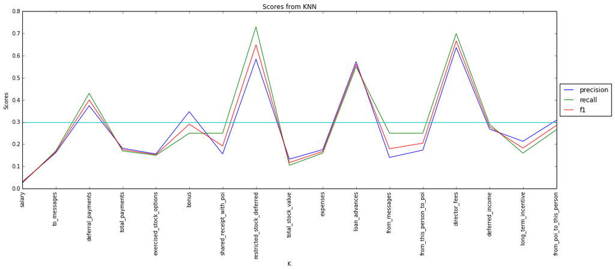

```python
%matplotlib inline
### Set the size of the plot
plt.rcParams["figure.figsize"] = (18,6)

### Set up the x-axis
k_values = range(len(precision_list))

other_features_no_restricted_stock = [i for i in other_feature if i!="restricted_stock"]

### Draw Salary histogram
plt.plot(k_values, precision_list, k_values, recall_list, k_values, f1_list)

x = [0,18]
y = [.3,.3]
plt.plot(x,y)

plt.xlim([0,len(precision_list)-1])

plt.legend(['precision','recall','f1'],loc='center left', bbox_to_anchor=(1, 0.5))
plt.xticks(k_values,other_features_no_restricted_stock, rotation='vertical')
plt.xlabel("K")
plt.ylabel("Scores")
plt.title("Scores from KNN")
plt.show()
```

Similar to the previous result there are 3 peaks at the exactly same features. I will print out the summary of these 3 peaks

```python
top_3_results = ["restricted_stock_deferred", "loan_advances", "director_fees"]

print "                       Precision  Recall      F1"
for i in top_3_results:
    print i
    ind = other_features_no_restricted_stock.index(i)
    print "                        {:.4f}    {:.4f}    {:.4f}".format(precision_list[ind], recall_list[ind], f1_list[ind])
```

```
                       Precision  Recall      F1
restricted_stock_deferred
                        0.5840    0.7300    0.6489
loan_advances
                        0.5729    0.5500    0.5612
director_fees
                        0.6364    0.7000    0.6667
```

# Multivariate Analysis

This will be the final round of achieving the highest scores from the data set. So far I conducted a univariate analysis to find the single features having the highest scores and then I calculated the number of features that optimized the scores the most. It turns out that **3** features are the best number of features to use and the scores get lower if I use more than this.

I created a new feature based on my observations from the analysis and the new feature showed good scores. So I need to recalculate the number of features that optimize the model the most using **SelectKBest** including this new feature.

## Selecting Features

```python
### Convert data_dict_new into numpy array
total_data = featureFormat(data_dict_new, total_features_list)

print total_data.shape

### Extract features from the data
features = total_data
features = np.delete(features, total_features_list.index("poi"), 1)

### Extract a label from the data
label = total_data[:,total_features_list.index("poi")]

### Rescale features
min_max_scaler = MinMaxScaler()
features = min_max_scaler.fit_transform(features)

### Import SelectKBest
from sklearn.feature_selection import SelectKBest
from sklearn.feature_selection import f_classif

pre_selected_list = []
features_by_importance = []
for k in range(1,20):
    selector = SelectKBest(f_classif, k=k)
    selector = selector.fit(features,label)

    features_list_wo_poi = [i for i in total_features_list if i!="poi"] ### features list without poi

    ### Print features chosen by SelectKBest
    selected_list = [features_list_wo_poi[i] for i in range(len(features_list_wo_poi)) if selector.get_support()[i]]

    print "K:", k
    for i in selected_list:
        if i not in pre_selected_list:
            print "\t", i
            features_by_importance.append(i)

    pre_selected_list = selected_list
```

```
(144L, 20L)
K: 1
	exercised_stock_options
K: 2
	total_stock_value
K: 3
	bonus
K: 4
	salary
K: 5
	deferred_income
K: 6
	long_term_incentive
K: 7
	restricted_stock
K: 8
	total_payments
K: 9
	shared_receipt_with_poi
K: 10
	loan_advances
K: 11
	expenses
K: 12
	from_poi_to_this_person
K: 13
	eso_deferred_income
K: 14
	from_this_person_to_poi
K: 15
	director_fees
K: 16
	to_messages
K: 17
	deferral_payments
K: 18
	from_messages
K: 19
	restricted_stock_deferred
```

So our new feature is chosen at the 13th position.

Note that in this code, the amount of the data has not been increased when using **SelectKBest** method. So the result is somewhat unreliable due to the fact that some of the features contain maybe less than 30 points while others contain more than 50. So next, I will use Decision Tree method to select features and in this time I will increase the amount of the data using **folds** parameter in the cross validation.

## Decision Tree

```python
### Use GridSearchCV to find the best parameters
from sklearn.grid_search import GridSearchCV

### Import DecisionTree Classifier
clf = tree.DecisionTreeClassifier()
param_grid = {
    'criterion': ['gini', 'entropy'],
    'splitter' : ['best', 'random'],
    'min_samples_split': range(2,9)
      }

### Set up the arrays for precision, recall and F1
precision_list = []
recall_list = []
f1_list = []

if 'poi' not in total_features_list:
    total_features_list.append('poi')

selected_features_list = [i for i in total_features_list if i != 'poi']
features_by_importance = []

### Calculate scores for each K value
for i in range(len(total_features_list)-1):
    print

    try:
        print "Dropped Feature:", features_by_importance[-1]
    except:
        pass

    selected_features_list_with_poi = ['poi']
    selected_features_list_with_poi.extend(selected_features_list)

    selected_data = featureFormat(data_dict_new, selected_features_list_with_poi)

    ### Split the data into labels and features
    labels, features = targetFeatureSplit(selected_data)

    ### Recale the features
    features = min_max_scaler.fit_transform(features)

    cv = StratifiedShuffleSplit(labels, 100, random_state = 42)

    clf_grid = GridSearchCV(clf, param_grid, cv = cv, scoring = 'recall')

    clf_grid.fit(features, labels)

    print clf_grid.best_params_

    clf.set_params(criterion=clf_grid.best_params_["criterion"],
                   splitter=clf_grid.best_params_["splitter"],
                   min_samples_split=clf_grid.best_params_["min_samples_split"])

    true_negatives = 0
    false_negatives = 0
    true_positives = 0
    false_positives = 0

    for train_idx, test_idx in cv:
        features_train = []
        features_test  = []
        labels_train   = []
        labels_test    = []
        for ii in train_idx:
            features_train.append( features[ii] )
            labels_train.append( labels[ii] )
        for jj in test_idx:
            features_test.append( features[jj] )
            labels_test.append( labels[jj] )

            features_test.append( features[jj])
            labels_test.append( labels[jj] )

        ### fit the classifier using training set, and test on test set
        clf.fit(features_train, labels_train)

        predictions = clf.predict(features_test)
        for prediction, truth in zip(predictions, labels_test):
            ### Assign prediction either 0 or 1
            if prediction < .5:
                prediction = 0
            else:
                prediction = 1

            if prediction == 0 and truth == 0:
                true_negatives += 1
            elif prediction == 0 and truth == 1:
                false_negatives += 1
            elif prediction == 1 and truth == 0:
                false_positives += 1
            elif prediction == 1 and truth == 1:
                true_positives += 1

    total_predictions = true_negatives + false_negatives + false_positives + true_positives
    accuracy = 1.0*(true_positives + true_negatives)/total_predictions
    precision = 1.0*true_positives/(true_positives+false_positives)
    recall = 1.0*true_positives/(true_positives+false_negatives)
    f1 = 2.0 * true_positives/(2*true_positives + false_positives+false_negatives)
    f2 = (1+2.0*2.0) * precision*recall/(4*precision + recall)


    print PERF_FORMAT_STRING.format(accuracy, precision, recall, f1, f2, display_precision = 5)
    importances = clf.feature_importances_

    precision_list.append(precision)
    recall_list.append(recall)
    f1_list.append(f1)

    ### Find the index of the feature with the lowest importance
    min_importance = min(importances)
    features_by_importance.append(selected_features_list[np.argmin(importances)])
    selected_features_list.remove(selected_features_list[np.argmin(importances)])
```

```
Dropped Feature: {'min_samples_split': 3, 'splitter': 'random', 'criterion': 'gini'}
	Accuracy: 0.80600	Precision: 0.24862	Recall: 0.22500	F1: 0.23622	F2: 0.22936

Dropped Feature: shared_receipt_with_poi
{'min_samples_split': 2, 'splitter': 'random', 'criterion': 'gini'}
	Accuracy: 0.80667	Precision: 0.30435	Recall: 0.35000	F1: 0.32558	F2: 0.33981

Dropped Feature: restricted_stock
{'min_samples_split': 2, 'splitter': 'random', 'criterion': 'entropy'}
	Accuracy: 0.81533	Precision: 0.30256	Recall: 0.29500	F1: 0.29873	F2: 0.29648

Dropped Feature: bonus
{'min_samples_split': 2, 'splitter': 'best', 'criterion': 'gini'}
	Accuracy: 0.81800	Precision: 0.32864	Recall: 0.35000	F1: 0.33898	F2: 0.34551

Dropped Feature: salary
{'min_samples_split': 2, 'splitter': 'best', 'criterion': 'gini'}
	Accuracy: 0.82333	Precision: 0.34146	Recall: 0.35000	F1: 0.34568	F2: 0.34826

Dropped Feature: deferral_payments
{'min_samples_split': 2, 'splitter': 'best', 'criterion': 'gini'}
	Accuracy: 0.82933	Precision: 0.35859	Recall: 0.35500	F1: 0.35678	F2: 0.35571

Dropped Feature: restricted_stock_deferred
{'min_samples_split': 2, 'splitter': 'best', 'criterion': 'gini'}
	Accuracy: 0.82067	Precision: 0.33171	Recall: 0.34000	F1: 0.33580	F2: 0.33831

Dropped Feature: to_messages
{'min_samples_split': 2, 'splitter': 'best', 'criterion': 'entropy'}
	Accuracy: 0.84533	Precision: 0.41111	Recall: 0.37000	F1: 0.38947	F2: 0.37755

Dropped Feature: total_stock_value
{'min_samples_split': 2, 'splitter': 'best', 'criterion': 'entropy'}
	Accuracy: 0.84400	Precision: 0.41584	Recall: 0.42000	F1: 0.41791	F2: 0.41916

Dropped Feature: loan_advances
{'min_samples_split': 2, 'splitter': 'best', 'criterion': 'entropy'}
	Accuracy: 0.84200	Precision: 0.41475	Recall: 0.45000	F1: 0.43165	F2: 0.44248

Dropped Feature: from_this_person_to_poi
```

[output cut: 19 more lines]

```
Dropped Feature: long_term_incentive
{'min_samples_split': 2, 'splitter': 'best', 'criterion': 'gini'}
	Accuracy: 0.83267	Precision: 0.39841	Recall: 0.50000	F1: 0.44346	F2: 0.47574

Dropped Feature: total_payments
{'min_samples_split': 3, 'splitter': 'best', 'criterion': 'entropy'}
	Accuracy: 0.86786	Precision: 0.54098	Recall: 0.49500	F1: 0.51697	F2: 0.50356

Dropped Feature: expenses
{'min_samples_split': 2, 'splitter': 'best', 'criterion': 'gini'}
	Accuracy: 0.80231	Precision: 0.35678	Recall: 0.35500	F1: 0.35589	F2: 0.35536

Dropped Feature: deferred_income
{'min_samples_split': 2, 'splitter': 'best', 'criterion': 'gini'}
	Accuracy: 0.86364	Precision: 0.28814	Recall: 0.34000	F1: 0.31193	F2: 0.32819
```

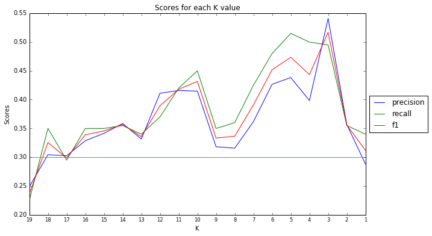

```python
%matplotlib inline
### Set the size of the plot
plt.rcParams["figure.figsize"] = (10,6)

### Set up the x-axis
k_values = range(1,len(recall_list)+1)

### Draw Salary histogram
plt.plot(k_values, precision_list, k_values, recall_list, k_values, f1_list)

x = [1,19]
y = [.3,.3]
plt.plot(x,y)

plt.xlim([1,19])

plt.legend(['precision','recall','f1'],loc='center left', bbox_to_anchor=(1, 0.5))
plt.xticks(k_values,['19','18','17','16','15','14','13','12','11','10','9','8','7','6','5','4','3','2','1'], size='small')
plt.xlabel("K")
plt.ylabel("Scores")
plt.title("Scores for each K value")
plt.show()
```

When **K=3**

- Chosen features: **exercised_stock_options**, **deferred_income** and **expenses**
- Accuracy: ~ 86.8%
- Precision: ~ 54.1%
- Recall: ~ 49.5 %

**Note:** Again, the result will vary everytime I run the code.

## KNN

I will calculate the scores using the features selected above: **exercised_stock_options**, **deferred_income** and **expenses**

```python
### Calculate scores
### if classi is Decision Tree then calculate scores of the pairs of the new feature with other features using Decision Tree
### if classi is KNN then scores using KNN

precision_list = []
recall_list = []
f1_list = []

selected_features_list_with_poi = ['poi', 'exercised_stock_options', 'deferred_income', 'expenses']

selected_data = featureFormat(data_dict_new, selected_features_list_with_poi)

### Split the data into labels and features
labels, features = targetFeatureSplit(selected_data)

### Recale the features
features = min_max_scaler.fit_transform(features)

### Set up the validation
cv = StratifiedShuffleSplit(labels, 100, random_state = 42)

### Set up the classifier
clf = KNeighborsClassifier()
param_grid = {
    'n_neighbors': [1,2,3,4,5,6,7,8,9,10],
    'weights': ['uniform', 'distance'],
    'algorithm': ['auto','ball_tree','kd_tree','brute']
    }

cv = StratifiedShuffleSplit(labels, 100, random_state = 42)

clf_grid = GridSearchCV(clf, param_grid, cv = cv, scoring = 'recall')

clf_grid.fit(features, labels)

clf.set_params(n_neighbors=clf_grid.best_params_["n_neighbors"],
               weights=clf_grid.best_params_["weights"],
               algorithm=clf_grid.best_params_["algorithm"])

print clf.get_params

true_negatives = 0
false_negatives = 0
true_positives = 0
false_positives = 0

### Getting train and test data sets
for train_idx, test_idx in cv:
    features_train = []
    features_test  = []
    labels_train   = []
    labels_test    = []
    for ii in train_idx:
        features_train.append( features[ii] )
        labels_train.append( labels[ii] )
    for jj in test_idx:
        features_test.append( features[jj] )
        labels_test.append( labels[jj] )

        features_test.append( features[jj])
        labels_test.append( labels[jj] )


    ### fit the classifier using training set, and test on test set
    clf.fit(features_train, labels_train)

    predictions = clf.predict(features_test)
    for prediction, truth in zip(predictions, labels_test):
        ### Assign prediction either 0 or 1
        if prediction < .5:
            prediction = 0
        else:
            prediction = 1

        if prediction == 0 and truth == 0:
            true_negatives += 1
        elif prediction == 0 and truth == 1:
            false_negatives += 1
        elif prediction == 1 and truth == 0:
            false_positives += 1
        elif prediction == 1 and truth == 1:
            true_positives += 1

try:
    total_predictions = true_negatives + false_negatives + false_positives + true_positives
    accuracy = 1.0*(true_positives + true_negatives)/total_predictions
    precision = 1.0*true_positives/(true_positives+false_positives)
    recall = 1.0*true_positives/(true_positives+false_negatives)
    f1 = 2.0 * true_positives/(2*true_positives + false_positives+false_negatives)
    f2 = (1+2.0*2.0) * precision*recall/(4*precision + recall)
    print "eso_deferred_income and", fe
    print PERF_FORMAT_STRING.format(accuracy, precision, recall, f1, f2, display_precision = 5)
    print RESULTS_FORMAT_STRING.format(total_predictions, true_positives, false_positives, false_negatives, true_negatives)
    print ""

    precision_list.append(precision)
    recall_list.append(recall)
    f1_list.append(f1)

except:
    print "Got a divide by zero when trying out:", clf
    print "Precision or recall may be undefined due to a lack of true positive predicitons.\n"
```

```
<bound method KNeighborsClassifier.get_params of KNeighborsClassifier(algorithm='auto', leaf_size=30, metric='minkowski',
           metric_params=None, n_jobs=1, n_neighbors=1, p=2,
           weights='uniform')>
eso_deferred_income and Got a divide by zero when trying out: KNeighborsClassifier(algorithm='auto', leaf_size=30, metric='minkowski',
           metric_params=None, n_jobs=1, n_neighbors=1, p=2,
           weights='uniform')
Precision or recall may be undefined due to a lack of true positive predicitons.
```

Let's use the top 3 features selected from **SelectKBest**.

```python
### Calculate scores
### if classi is Decision Tree then calculate scores of the pairs of the new feature with other features using Decision Tree
### if classi is KNN then scores using KNN

precision_list = []
recall_list = []
f1_list = []

selected_features_list_with_poi = ['poi', 'exercised_stock_options', 'total_stock_value', 'bonus']

selected_data = featureFormat(data_dict_new, selected_features_list_with_poi)

### Split the data into labels and features
labels, features = targetFeatureSplit(selected_data)

### Recale the features
features = min_max_scaler.fit_transform(features)

### Set up the validation
cv = StratifiedShuffleSplit(labels, 100, random_state = 42)

### Set up the classifier
clf = KNeighborsClassifier()
param_grid = {
    'n_neighbors': [1,2,3,4,5,6,7,8,9,10],
    'weights': ['uniform', 'distance'],
    'algorithm': ['auto','ball_tree','kd_tree','brute']
    }

cv = StratifiedShuffleSplit(labels, 100, random_state = 42)

clf_grid = GridSearchCV(clf, param_grid, cv = cv, scoring = 'recall')

clf_grid.fit(features, labels)

clf.set_params(n_neighbors=clf_grid.best_params_["n_neighbors"],
               weights=clf_grid.best_params_["weights"],
               algorithm=clf_grid.best_params_["algorithm"])

print clf.get_params

true_negatives = 0
false_negatives = 0
true_positives = 0
false_positives = 0

### Getting train and test data sets
for train_idx, test_idx in cv:
    features_train = []
    features_test  = []
    labels_train   = []
    labels_test    = []
    for ii in train_idx:
        features_train.append( features[ii] )
        labels_train.append( labels[ii] )
    for jj in test_idx:
        features_test.append( features[jj] )
        labels_test.append( labels[jj] )

        features_test.append( features[jj])
        labels_test.append( labels[jj] )


    ### fit the classifier using training set, and test on test set
    clf.fit(features_train, labels_train)

    predictions = clf.predict(features_test)
    for prediction, truth in zip(predictions, labels_test):
        ### Assign prediction either 0 or 1
        if prediction < .5:
            prediction = 0
        else:
            prediction = 1

        if prediction == 0 and truth == 0:
            true_negatives += 1
        elif prediction == 0 and truth == 1:
            false_negatives += 1
        elif prediction == 1 and truth == 0:
            false_positives += 1
        elif prediction == 1 and truth == 1:
            true_positives += 1

try:
    total_predictions = true_negatives + false_negatives + false_positives + true_positives
    accuracy = 1.0*(true_positives + true_negatives)/total_predictions
    precision = 1.0*true_positives/(true_positives+false_positives)
    recall = 1.0*true_positives/(true_positives+false_negatives)
    f1 = 2.0 * true_positives/(2*true_positives + false_positives+false_negatives)
    f2 = (1+2.0*2.0) * precision*recall/(4*precision + recall)
    print "eso_deferred_income and", fe
    print PERF_FORMAT_STRING.format(accuracy, precision, recall, f1, f2, display_precision = 5)
    print RESULTS_FORMAT_STRING.format(total_predictions, true_positives, false_positives, false_negatives, true_negatives)
    print ""

    precision_list.append(precision)
    recall_list.append(recall)
    f1_list.append(f1)

except:
    print "Got a divide by zero when trying out:", clf
    print "Precision or recall may be undefined due to a lack of true positive predicitons.\n"
```

```
<bound method KNeighborsClassifier.get_params of KNeighborsClassifier(algorithm='auto', leaf_size=30, metric='minkowski',
           metric_params=None, n_jobs=1, n_neighbors=1, p=2,
           weights='uniform')>
eso_deferred_income and Got a divide by zero when trying out: KNeighborsClassifier(algorithm='auto', leaf_size=30, metric='minkowski',
           metric_params=None, n_jobs=1, n_neighbors=1, p=2,
           weights='uniform')
Precision or recall may be undefined due to a lack of true positive predicitons.
```

# Final Thought

#### Usage of Parameter Tuning

I used parameter tuning a lot of times for this project using **GridSearchCV**. Depending on the data we have, parameters of the model have to be adjusted to achieve the best solution. Thanks to the **sklearn** library, finding such parameters is not very difficult.

#### Usage of Evaluation Metrics

When evaluating the results, I calculated **Accuracy**, **Precision**, and **Recall**. I didn't put much emphasis on **Accuracy**. **Accuracy** is calculated by summing true positives and true negatives and dividing it by total predictions. Most of the time this value is above **70%**. Due to very small amount of POIs, assuming everything to be non-POI can give us a good **Accuracy**. So this score is not very reliable in deciding the best algorithm.

So I focus on using **Precision** and **Recall**. A good **Precision** tells you that when the algorithm identify POI groups from the test set, then most of them will be true POIs. A good **Recall** values tells you that most of the true POIs in the test set will be identified as POIs by the algorithm. I thought that both of these scores are equally important when choosing the best algorithm.

#### Discuss validation and its importance.

Validation is important when evaluating the algorithms. The most basic validation is Test and Train split with certain percentage. For example, if I use 70% then I take 70% of the data as a train set and 30% of the data as a test set. The algorithm is trained by the 70% of the data and it will be applied to the 30% and the result will be analyzed.

Test and Train is just one of many validations. Analyzing the algorithms using validations is very important because if we create an algorithm then we need to know if the algorithm really works before we apply this algorithm to the real world. Using the existing data set we have, we can estimate and predict what would happend if the algorithm is used in the real world.

We need to choose the validation properly because sometimes depending on the data set we have, certain types of validations won't work very well. For example, in this project, using Train and Test validation won't provide us a reliable result because when dividing the data set into train and test, with a high probability, the test set won't contain any POIs, due to a small number of POI in the data set.

#### Validation Strategy

I used **StratifiedShuffleSplit** as a cross validation for this project. I thought this is the best cross validation to be used because it increases the size of the data points randomly and provides the better calculation. Due to small number of POIs in the data set, Test and Train split can cause zero POI in test set very frequently, so it won’t give very good calculation.

#### Further Note

For this final project, I first investigated the overall data set first. I checked the number features in the data set, the number of POIs, and see if there are any features with too many zeros or missing values. Then, I found an outlier and realized that there was “Total” summing all the features in the data set. I got rid of this “Total” and the data showed better plots.

**Note:** *poi_id.py* includes the result with the best scores from my investigation and it can be tested by running *tester.py*.